# MECH481A6: Engineering Data Analysis in R

Chapter 5 Homework: Exploring Univariate Data

Student Name

03 October, 2023

# Grading

We will grade the **knitted** PDF or HTML document from within your private GitHub repository. Remember to make regular, small commits (e.g., at least one commit per question) to save your work. We will grade the latest knit, as long as it occurs *before* the start of the class in which we advance to the next chapter. As always, reach out with questions via GitHub Issues or during office hours.

# Data

You are probably sick of seeing the ozone data, but there’s still more to do with the file. Ozone concentration measurement is considered univariate, thus we can use basic exploratory data analysis approaches to examine the data.

# Preparation

Load the necessary R packages into your R session.

```r
# load packages
library(tidyverse)
library(knitr)
library(ggplot2)

csv_path <- "/Users/genevieve/Reyland-MECH476/data/ftc_o3.csv"
# I cannot get the ../../Reyland-MECH476/data/ft_o3.csv to work in the readr::read_csv(file=) I've tried moving the file elsewhere too but it doesn't work. This csv_path works for me and it's not too much extra work. I'm not sure what's going wrong. It worked in ch3 but stopped in ch4 and then wouldn't run in ch3 again after I submitted.
```

Recreate the pipe of `dplyr` functions that you used to import the data, select and rename the variables listed below, drop missing observations, and assign the output with a good name.

- `sample_measurement` renamed as `ozone_ppm` (ozone measurement in ppm)
- `datetime` (date in YYYY-MM-DD format and time of measurement in HH:MM:SS)

```r
# ozone: import, select, drop missing observations, rename

# Read the CSV file using the relative path
  ozone_data <- readr::read_csv(file = csv_path) %>%
    dplyr::select(sample_measurement,
                  datetime) %>%
    drop_na() %>%
    dplyr::rename(ozone_ppm = sample_measurement)
```

Check that the data imported correctly.

```r
# examine dataframe object
ozone_data
```

```
## # A tibble: 16,914 × 2
##    ozone_ppm datetime
##        <dbl> <dttm>
##  1     0.017 2019-01-01 07:00:00
##  2     0.017 2019-01-01 08:00:00
##  3     0.017 2019-01-01 09:00:00
##  4     0.017 2019-01-01 10:00:00
##  5     0.015 2019-01-01 11:00:00
##  6     0.017 2019-01-01 12:00:00
##  7     0.028 2019-01-01 13:00:00
##  8     0.03  2019-01-01 14:00:00
##  9     0.036 2019-01-01 15:00:00
## 10     0.036 2019-01-01 16:00:00
## # ℹ 16,904 more rows
```

# Chapter 5 Homework: Exploring Univariate Data

Through Question 5, you will use all of the available ozone measurements from January 2019 through January 2020. Starting in Question 6, you will use a subset of the dataset: ozone concentration measurements on July 4, 2019.

## Question 1: Definitions

Guess the location, dispersion, and shape of ozone concentration data, based on the definitions of each described in the coursebook. No code needed; just use your intuition. For shape, take a look at the coursebook appendix on reference distributions. –> Based on the data, I assume this data will look like an increase as the ozone will most likely increase as the months go on and as people start driving more in the summer months. Then they’ll decrease when the weather gets cooler again. The amount of ozone might increase over the year as the number of cars on the road has only increased but will probably go down a little as the year goes on and people travel less.

## Question 2: Quartiles

```r
# calculate quantiles of ozone concentration
set.seed(1)
ozone_dist <- runif(n = 1000,
                    min = 0,
                    max = 100)
ozone_quart <- quantile(ozone_dist,
                        probs = seq(0,1,0.25)) %>%
  round(1)
```

### Extra Credit

Create [a similar table](https://smogdr.github.io/edar_coursebook/eda1.html#descriptive-statistics) for `ozone_ppm`. Hint: You will need to investigate table options in the `knitr` package.

## Question 3: Cumulative Distribution Plot

Using either relevant `ggplot2` `geom` option, create a cumulative distribution plot of `ozone_ppm`. Tweak the axis ranges for optimal data representation, using `scale_*_continuous()` with `breaks =` and `minor_breaks =` arguments. Add axis labels, title, subtitle, and theme.

[figure not shown]

```r
# plot cumulative distribution of ozone concentration
ozone_date <- as.Date(ozone_data$datetime)
ggplot(data = ozone_data) +
  geom_step(aes(x = ozone_date),
                stat = "ecdf") +
  labs(x = "Month",
       y = "Ozone ppm",
       title = "Cumulative Distribution Plot of Ozone ppm vs Month",
       subtitle = "Ozone levels in Fort Collins between January 2019 and January 2020") +
  scale_y_continuous(limits = c(-0.05, 1.05),
                     expand = c(0,0),
                     breaks = seq(from = 0,
                                  to = 1,
                                  by = 0.1)) +
  scale_x_date(date_breaks = "months" , date_labels = "%b-%y") +
  theme_bw()
```

## Question 4: Histogram

Create a histogram of `ozone_ppm`. Within the `geom`, mess with the number of bins (e.g., 20, 50, 75, 100, 200) to explore the true shape and granularity of the data. Match the plot style (e.g., title, subtitle, axis labels, theme) you chose in Question 3, with the relevant adjustments such as “Histogram” instead of “Cumulative Distribution Plot”.

[figure not shown]

```r
# create histogram of ozone concentration
ggplot(data = ozone_data) +
  geom_histogram(aes(x = ozone_date),
                     bins = 100,
                     color = "navy") +
   labs(x = "Month",
       y = "Ozone ppm",
       title = "Histogram Plot of Ozone ppm vs Month",
       subtitle = "Ozone levels in Fort Collins between January 2019 and January 2020") +
   scale_y_continuous(breaks = seq(from = 0,
                                  to = 200,
                                  by = 20)) +
  scale_x_date(date_breaks = "months" , date_labels = "%b-%y")
```

```r
theme_bw
```

[output not shown]

### Question 5: Concept

What mathematical concept is a histogram (Q4) attempting to visualize? –> histograms represent the frequency of an occurance

## Question 8: Boxplot

Generate a boxplot of ozone concentration on the y-axis with a title, subtitle, y-axis label, and theme consistent with the style of the previous two plots. Use quotes (`""`) as the `x` arguments within the calls to the aesthetic and labels to remove the x-axis scale and label.

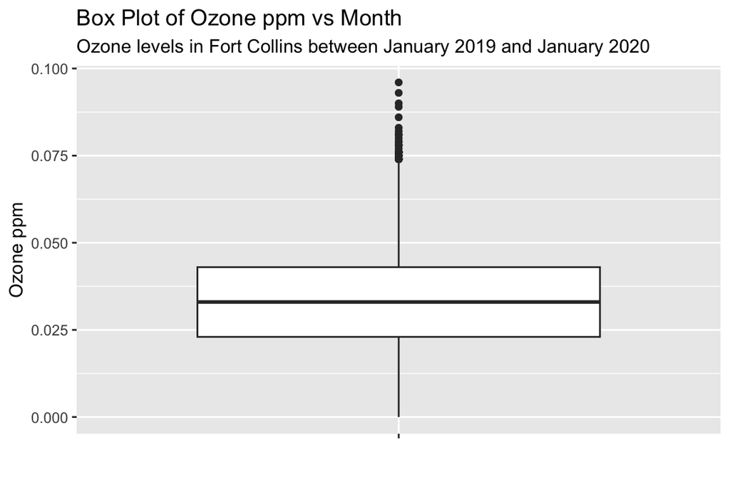

```r
# create ozone boxplot
ggplot(data = ozone_data,
       mapping = aes(x = "",
                     y = ozone_ppm)) +
  geom_boxplot() +
  labs(x = "",
       y = "Ozone ppm",
       title = "Box Plot of Ozone ppm vs Month",
       subtitle = "Ozone levels in Fort Collins between January 2019 and January 2020")
```

```r
theme_bw
```

[output not shown]

# Subset Data

Use the following code to create a dataframe for use in the remaining questions. These ozone concentration measurements were taken on July 4, 2019 in Fort Collins, CO. This code detects certain characters with the `datetime` object and filters to observations containing those characters. There are other ways this could have been done (e.g., `dplyr::filter()` with `%in%` operator).

```r
# create subset of data with only one day to examine daily pattern
# I did not ask you to code this because we have not discussed dates or stringr
# You need to uncomment the below three lines and run it; check object names
 ozone_day <- ozone_data %>%
   dplyr::filter(stringr::str_detect(string = datetime,
                                     pattern = "2019-07-04"))
```